# Introdução ao Python

# Parte 3 — Condicionais e repetição

## `if` / `elif` / `else`

```python
idade = 45

if idade < 18:
    faixa = "crianca_adolescente"
elif idade < 60:
    faixa = "adulto"
else:
    faixa = "idoso"
```

- O Python testa **de cima para baixo** e para no primeiro `True`
- Por isso a **ordem importa**: se o primeiro teste fosse `idade < 60`, ninguém seria “idoso”
- `else` é o “resto”: não tem condição, é o que sobrou
- Dois-pontos no fim de cada linha e **4 espaços de recuo** no bloco

## Exercício 7 no notebook

**Exercício 7 — Faixa etária.** Classifique `idade` em `faixa_etaria`: menos de 18 → `"crianca_adolescente"`; de 18 a 59 → `"adulto"`; 60 ou mais → `"idoso"`.

```python
# EXERCICIO 7
idade = 45

if ...:
    faixa_etaria = ...
elif ...:
    faixa_etaria = ...
else:
    faixa_etaria = ...
```

As palavras vão entre aspas, em minúsculas e **sem acento**.

## Solução do Exercício 7

```python
# EXERCICIO 7
idade = 45

if idade < 18:
    faixa_etaria = "crianca_adolescente"
elif idade < 60:
    faixa_etaria = "adulto"
else:
    faixa_etaria = "idoso"
```

```
  [OK]     [ex7] {'idade': 17} -> 'crianca_adolescente'
  [OK]     [ex7] {'idade': 18} -> 'adulto'
  [OK]     [ex7] {'idade': 59} -> 'adulto'
  [OK]     [ex7] {'idade': 60} -> 'idoso'
  Nota: 10.0 / 10   (7 de 7 casos)
```

O corretor testa justamente as **bordas** (17/18 e 59/60): é ali que `>` e `>=` se separam.

## O laço `for`

```python
idades = [46, 27, 12, 63]

for idade in idades:
    print(idade)

for numero in range(5):      # 0, 1, 2, 3, 4
    print(numero)

for indice, idade in enumerate(idades):
    print(indice, idade)
```

- `for` **percorre** uma sequência: a cada volta, a variável assume o próximo valor
- O bloco indentado é repetido uma vez por item
- `range(n)` gera 0 até n−1 (útil para repetir *n* vezes)

## Acumuladores: somar dentro do laço

```python
idades = [46, 27, 12, 63]

soma = 0                 # 1. começa em zero, ANTES do laço
for idade in idades:     # 2. para cada item...
    soma = soma + idade  #    ...some ao acumulador
                         # 3. depois do laço, soma = 148
media = soma / len(idades)
```

O padrão é sempre o mesmo:

1. **inicialize** fora do laço (`soma = 0`)
2. **atualize** dentro do laço (`soma = soma + ...`)
3. **use** o resultado depois do laço

## Exercício 8 no notebook

**Exercício 8 — Laço com acumulador.** Some as idades **com um laço `for`** (o enunciado pede o laço: **não use `sum()`**) e calcule `media`.

```python
# EXERCICIO 8
idades = [46, 27, 12, 63]

soma = 0
for idade in idades:
    soma = ...

media = ...
```

Dica: o corretor recusa `sum()` — se você usar, ele explica por quê.

## Solução do Exercício 8

```python
# EXERCICIO 8
idades = [46, 27, 12, 63]

soma = 0
for idade in idades:
    soma = soma + idade

media = soma / len(idades)
```

```
  [OK]     [ex8] {'idades': [46, 27, 12, 63]} -> 37.0
  [OK]     [ex8] {'idades': [1, 2]} -> 1.5
  Nota: 10.0 / 10   (4 de 4 casos)
```

O pandas faz exatamente isto por dentro, em C, para 16 mil linhas de uma vez — e é por isso que ele é rápido.

## `for` + `if`: contando casos

```python
idades = [46, 27, 12, 63]

quantos_idosos = 0
for idade in idades:
    if idade >= 60:
        quantos_idosos = quantos_idosos + 1
```

- O `if` dentro do `for` **filtra**: só conta quem interessa
- Mesmo padrão de acumulador, mas somando `1` em vez do valor
- `+=` é o atalho: `quantos_idosos += 1`

Este é o “feijão com arroz” da análise de dados: **percorrer e contar por categoria**.

## Exercício 9 no notebook

**Exercício 9 — `for` + `if`.** Conte quantas pessoas da lista têm **60 anos ou mais** e guarde em `quantos_idosos`.

```python
# EXERCICIO 9
idades = [46, 27, 12, 63]

quantos_idosos = 0
for idade in idades:
    if ...:
        quantos_idosos = ...

print(quantos_idosos)
```

O corretor testa listas vazias também — uma lista vazia deve devolver `0`, não erro.

## Solução do Exercício 9

```python
# EXERCICIO 9
idades = [46, 27, 12, 63]

quantos_idosos = 0
for idade in idades:
    if idade >= 60:
        quantos_idosos += 1

print(quantos_idosos)
```

```
  [OK]     [ex9] {'idades': [46, 27, 12, 63]} -> 1
  [OK]     [ex9] {'idades': [60, 61, 59]} -> 2
  [OK]     [ex9] {'idades': [12, 7]} -> 0
  [OK]     [ex9] {'idades': []} -> 0
```

## `while` (só para reconhecer)

```python
contador = 0
while contador < 5:
    print(contador)
    contador = contador + 1     # sem esta linha, o laço nunca termina
```

- `while` repete **enquanto** a condição for verdadeira
- Use quando não se sabe quantas voltas serão — “repita até dar certo”
- Risco: se a condição nunca virar `False`, o laço não termina (`Ctrl+C` interrompe no terminal; no Colab, o botão de stop)
- Em análise de dados, `for` aparece muito mais que `while`

# Parte 4 — Funções

## `def`: dar nome a um trecho de código

```python
def faixa_etaria(idade):          # def nome(argumentos):
    if idade < 18:
        return "crianca_adolescente"
    elif idade < 60:
        return "adulto"
    else:
        return "idoso"


faixa_etaria(45)      # 'adulto'
faixa_etaria(70)      # 'idoso'
```

- **argumento**: o que entra (aqui, `idade`)
- **`return`**: o que sai — a função **devolve** um valor
- `return` **encerra** a função na hora
- **`print` não é `return`**: imprimir mostra na tela, devolver entrega o valor para quem chamou

## Por que funções

- **Não repetir**: (*DRY: don’t repeat yourself*) escrevemos a regra uma vez, usamos mil
- **Dar nome ao que se faz**: `conta_acima(idades)` se lê melhor que seis linhas de laço
- **Testar em separado**: uma função com uma responsabilidade é fácil de conferir
- **Compor**: funções chamam funções — é assim que se constrói um pipeline de análise

```python
# a mesma lógica, agora reutilizável
def conta_acima(idades, limite=60):
    quantos = 0
    for idade in idades:
        if idade >= limite:
            quantos += 1
    return quantos

idosos = conta_acima(idades)          # limite padrão 60
adultos = conta_acima(idades, 18)     # limite 18
```

## Exercício 10 no notebook

**Exercício 10 — Sua primeira função.** Escreva `faixa_etaria(idade)` que **devolve** `"crianca_adolescente"`, `"adulto"` ou `"idoso"`.

```python
# EXERCICIO 10
def faixa_etaria(idade):
    if ...:
        return ...
    elif ...:
        return ...
    else:
        return ...


print(faixa_etaria(45))
```

O corretor **chama** a sua função com 5, 17, 18, 59, 60 e 91.

## Solução do Exercício 10

```python
# EXERCICIO 10
def faixa_etaria(idade):
    if idade < 18:
        return "crianca_adolescente"
    elif idade < 60:
        return "adulto"
    else:
        return "idoso"


print(faixa_etaria(45))
```

```
  [OK]     faixa_etaria(17) -> 'crianca_adolescente'
  [OK]     faixa_etaria(60) -> 'idoso'
  Nota: 10.0 / 10   (6 de 6 casos)
```

Compare com o Exercício 7: **mesma lógica**, agora reaproveitável e testável.

## Exercício 11 no notebook

**Exercício 11 — Valor padrão.** Escreva `conta_acima(idades, limite=60)`: devolve **quantas** idades são **maiores ou iguais** a `limite`. Chamada só com a lista, usa 60.

```python
# EXERCICIO 11
def conta_acima(idades, limite=60):
    quantos = 0
    for idade in idades:
        if ...:
            quantos = ...
    return ...


print(conta_acima([46, 27, 12, 63]))
```

O `=60` fica **só na linha `def`** — na chamada você passa ou não o limite.

## Solução do Exercício 11

```python
# EXERCICIO 11
def conta_acima(idades, limite=60):
    quantos = 0
    for idade in idades:
        if idade >= limite:
            quantos += 1
    return quantos


print(conta_acima([46, 27, 12, 63]))       # 1
print(conta_acima([46, 27, 12, 63], 30))  # 2
```

```
  [OK]     conta_acima([46, 27, 12, 63]) -> 1
  [OK]     conta_acima([46, 27, 12, 63], 30) -> 2
  Nota: 10.0 / 10   (6 de 6 casos)
```

## Resumo dos fundamentos

```python
# variáveis e tipos
media = 41.99            # float
nome = "Parda"           # str
prioridade = True        # bool
n = int("46")            # conversão

# estruturas
idades = [46, 27, 12]
pessoa = {"idade": 46}
tamanho = (16639, 21)

# decisão e repetição
if n >= 60:
    ...
for idade in idades:
    ...

# funções
def conta_acima(idades, limite=60):
    ...
    return quantos
```

Se você conseguiu fazer os 11 exercícios, você já programa em Python no nível necessário para a próxima parte.

# Tabelas

*“Desde os tempos mais primórdios”*

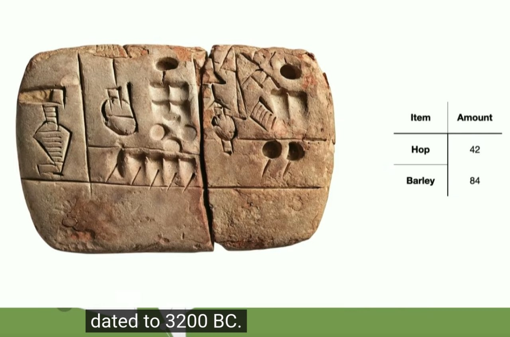

Primeira tabela

Um dos primeiros registros de tabela da humanidade, em cuneiforme. Encontrado em Uruk (atual Iraque), 3200 AEC.

# O que é um CSV

## CSV = *Comma-Separated Values*

Um arquivo de texto puro, em que **cada linha é um registro** e **cada valor é separado por um caractere** (vírgula, ponto e vírgula, tabulação).

```
IDADE,SEXO,GRAU_INSTRUCAO,COR_RACA,REGIONAL
46,MASCULINO,Fundamental completo,Parda,NOROESTE
27,MASCULINO,Fundamental incompleto,Parda,HIPERCENTRO
33,FEMININO,Medio completo,Preta,CENTRO SUL
```

- A **primeira linha** é o cabeçalho: os nomes das colunas (as “variáveis”)
- Cada linha seguinte é um caso (aqui, uma pessoa cadastrada)
- Não tem formatação, não tem fórmulas, não tem tipo: **é tudo texto** até alguém dizer o contrário

## CSV: as armadilhas que sempre aparecem

- **Separador**: no Brasil o Excel e o LibreOffice costumam salvar com `;` em vez de `,` (por causa da vírgula decimal)
- **Decimal**: `41,99` (pt-BR) x `41.99` (padrão internacional) — ler com o separador errado devolve texto
- **Codificação**: UTF-8 x latin-1; acentos viram `Ã©` quando o encoding está errado
- **Lixo no começo**: linhas de título e notas antes do cabeçalho (comum em dados de governo)
- **Texto disfarçado de número**: `"R$ 1.200,00"`, `" 46"`, `"N/A"`, células vazias
- **Planilha não é banco de dados**: Excel “ajuda” e converte `1/2` em data, tira zeros à esquerda de CEP, e altera o arquivo sem avisar

## Abrir CSV com código x abrir no Excel

- No Excel você **vê** a tabela; no código você **descreve** o que fazer com ela
- O código **guarda o caminho**: daqui a seis meses, o script refaz a análise; a planilha, não
- O código **não cansa**: 16 mil linhas ou 16 milhões, o comando é o mesmo
- O código **documenta as decisões**: por que descartamos aquelas 300 linhas? Está escrito

# Nossa base de dados

## População de rua de Belo Horizonte

- **Fonte**: Cadastro Único da população em situação de rua, publicado no portal de dados abertos da PBH https://dados.pbh.gov.br/dataset/populacao-de-rua
- **Arquivo**: `poprua_cadunico_BH.csv`
- **16.639 registros** × **21 colunas** (referência: 07/2026)
- O que tem dentro: `IDADE`, `SEXO`, `COR_RACA`, `GRAU_INSTRUCAO`, `REGIONAL`, `TEMPO_VIVE_NA_RUA`, se recebe `BOLSA_FAMILIA`, se é `PcD`, `VAL_REMUNERACAO_MES_PASSADO`, entre outras

## O que é “análise de dados”, afinal

1. **Perguntar** — uma pergunta que os dados podem responder
2. **Obter** — baixar, raspar, pedir acesso
3. **Limpar** — o trabalho que ninguém vê e que toma 60% do tempo
4. **Explorar** — descrever, comparar, agrupar
5. **Visualizar** — mostrar o padrão
6. **Interpretar** — a parte que é da Sociologia, não do computador

Hoje vamos fazer os passos 4 e 5 com uma base já limpa — e no caminho aprender a linguagem que torna isso possível.

# Pandas: a caixa de ferramentas

[figure not shown]

pandas

## O que é o pandas

> “O pandas será uma ferramenta principal de interesse em boa parte do restante do livro. Ele contém estruturas de dados e ferramentas para manipulação de dados, projetadas para agilizar e facilitar a limpeza e a análise de dados em Python.”

> — McKinney, p. 185
- **pandas** é a biblioteca que traz a **tabela** para o Python
- Duas estruturas: **`Series`** (uma coluna) e **`DataFrame`** (a tabela inteira)
- Feito para dados **tabulares e heterogêneos**: texto, número e data na mesma tabela
- O nome vem de *panel data* (dados em painel) e de uma brincadeira com *Python data analysis*

## Importar e ler o CSV

```python
import pandas as pd          # convenção universal: pd

df = pd.read_csv("poprua_cadunico_BH.csv")

df.head()                    # as 5 primeiras linhas
df.shape                     # (16639, 21)
```

- `import pandas as pd` — traz a biblioteca com o apelido (*alias*) `pd`
- `pd.read_csv("arquivo.csv")` — lê o arquivo do diretório atual e devolve um **DataFrame**
- `head()` mostra as primeiras linhas: é o primeiro olhar, sempre

## Exercício 12 no notebook

**Exercício 12 — Importar a base.** Importe o pandas como `pd` e leia `poprua_cadunico_BH.csv` em `df_poprua`.

```python
# EXERCICIO 12
... pandas as ...

df_poprua = ...
```

O corretor da atividade confere três coisas: que é um DataFrame, que tem **todas** as linhas e colunas, e que `IDADE`, `SEXO` e `GRAU_INSTRUCAO` estão lá.

## Solução do Exercício 12

```python
# EXERCICIO 12
import pandas as pd

df_poprua = pd.read_csv("poprua_cadunico_BH.csv")
df_poprua.head()
```

```
  [OK]     df_poprua é um DataFrame do pandas
  [OK]     o arquivo foi lido por completo (todas as linhas e colunas)
  [OK]     as colunas IDADE, SEXO e GRAU_INSTRUCAO estão presentes
  Nota: 10.0 / 10   (3 de 3 checagens)
```

Deu certo? Então você acabou de transformar um CSV em uma tabela na memória do Python.

## Lendo dados de arquivos

O pandas lê dados de diferentes formatos: CSV, Excel, JSON, HTML, SQL…

## Inspecionar: os primeiros cinco comandos

```python
df_poprua.head()          # primeiras linhas
df_poprua.tail(3)         # últimas 3
df_poprua.shape           # (16639, 21)  -> linhas e colunas
df_poprua.columns         # os nomes das colunas
df_poprua.dtypes          # o tipo de cada coluna
df_poprua.info()          # tudo isso junto + memória usada
```

Sempre nessa ordem: **quantas linhas? quantas colunas? que tipos?** Sem isso, qualquer análise é chute.

## Exercício 13 no notebook

**Exercício 13 — Dimensões.** Guarde em `dimensoes` o formato de `df_poprua` e mostre na tela.

```python
# EXERCICIO 13
dimensoes = ...

print(dimensoes)
```

`shape` devolve uma **tupla** `(linhas, colunas)` — um dos tipos que vimos na Parte 2.

## Solução do Exercício 13

```python
# EXERCICIO 13
dimensoes = df_poprua.shape

print(dimensoes)
```

```
(16639, 21)
```

16.639 registros e 21 variáveis. Você já sabe `dimensoes[0]` (linhas) e `dimensoes[1]` (colunas) sem consultar nada.

## Selecionar uma coluna: a `Series`

```python
idade = df_poprua["IDADE"]        # uma Series
tipo = df_poprua["GRAU_INSTRUCAO"]

type(idade)                       # pandas.Series
idade.head()                      # 0    46
                                  # 1    27
                                  # ...
idade.mean()                      # 41.99
idade.max()                       # 91
```

- **Colchetes com o nome da coluna**: `df["coluna"]` devolve uma `Series`
- A `Series` tem **índice** (à esquerda) e valores (à direita)
- Uma `Series` aceita `mean()`, `max()`, `value_counts()`… sem loop/laço nenhum

## Exercício 14 no notebook

**Exercício 14 — Selecionar coluna.** Selecione a coluna `GRAU_INSTRUCAO` e guarde em `escolaridade`.

```python
# EXERCICIO 14
escolaridade = df_poprua[...]
```

O corretor confere **o nome da Series** e se todos os 16.639 valores batem com a coluna da base.

## Solução do Exercício 14

```python
# EXERCICIO 14
escolaridade = df_poprua["GRAU_INSTRUCAO"]
```

Duas checagens passam: o `name` da Series é `GRAU_INSTRUCAO` e os valores são os mesmos da base. Selecionar a coluna errada (por exemplo `SEXO`) zera o exercício — e a mensagem diz qual falhou.

## Contar categorias: `value_counts`

```python
df_poprua["GRAU_INSTRUCAO"].value_counts()

# Fundamental incompleto        7537
# Medio completo                3123
# Fundamental completo          2520
# Medio incompleto              2177
# Sem instrucao                  995
# Superior incompleto ou mais    269
# Nao Informado                   18
```

- Ordenado do mais frequente para o menos frequente
- `unique()` devolve só os valores distintos; `nunique()` conta quantos são
- É o primeiro comando de **qualquer** variável categórica

## Exercício 15 no notebook

**Exercício 15 — Frequências.** Conte quantas pessoas há em cada grau de instrução (`GRAU_INSTRUCAO`) e guarde em `contagem`.

```python
# EXERCICIO 15
contagem = df_poprua[...]...()
```

O corretor confere as 7 categorias e cada contagem, uma por uma.

## Solução do Exercício 15

```python
# EXERCICIO 15
contagem = df_poprua["GRAU_INSTRUCAO"].value_counts()
```

```
  [OK]     contagem traz uma contagem por grau de instrução
  [OK]     as contagens conferem com a base
  Nota: 10.0 / 10   (2 de 2 checagens)
```

Repare que `contagem` é uma `Series` — índice = categoria, valores = contagem. Quase um dicionário.

## Filtrar linhas: a máscara booleana

```python
# 1) a condição vira uma coluna de True/False
df_poprua["IDADE"] > 60          # 0 False, 1 False, ... , 1126 True

# 2) essa coluna seleciona as linhas
df_60mais = df_poprua[df_poprua["IDADE"] > 60]

df_60mais.shape                  # (1126, 21)
```

- É o `for` + `if` do Exercício 9, vetorizado: **uma condição, todas as linhas**
- Cuidado com a repetição: `df_poprua[df_poprua["IDADE"] > 60]` — o nome aparece duas vezes
- Duas condições: `&` (e) e `|` (ou), cada uma **entre parênteses**

## Exercício 16 no notebook

**Exercício 16 — Filtrar por um valor.** Filtre as pessoas com **mais de 60 anos** (`IDADE > 60`) e guarde em `df_60mais`.

```python
# EXERCICIO 16
df_60mais = ...
```

Atenção ao sinal: **mais de 60** exclui quem tem exatamente 60. O corretor confere linha por linha.

## Solução do Exercício 16

```python
# EXERCICIO 16
df_60mais = df_poprua[df_poprua["IDADE"] > 60]
```

```
  [OK]     df_60mais é um DataFrame
  [OK]     entraram exatamente as pessoas com mais de 60 anos
  Nota: 10.0 / 10   (2 de 2 checagens)
```

1.126 pessoas com mais de 60 anos na base — cerca de 7% do total.

## `query`: filtro em forma de frase

```python
df_filtro = df_poprua.query('IDADE > 60 and SEXO == "FEMININO"')
df_filtro.shape                  # (380, 21)

# equivalente com máscara:
df_filtro = df_poprua[(df_poprua["IDADE"] > 60) & (df_poprua["SEXO"] == "FEMININO")]
```

- `query` recebe o filtro como **texto**: mais legível quando há duas ou três condições
- Texto vai entre aspas — e, dentro dele, aspas duplas ou simples nas categorias
- `and`, `or`, `not` funcionam como em Python (não precisa de `&`)

## Exercício 17 no notebook

**Exercício 17 — Duas condições com `query`.** Filtre `SEXO == "FEMININO"` **e** `PcD == "SIM"` usando `query`, guardando em `df_filtro`.

```python
# EXERCICIO 17
df_filtro = df_poprua.query('...')
```

O corretor **exige** o `query` — resolver com máscara funciona, mas o exercício é sobre o método.

## Solução do Exercício 17

```python
# EXERCICIO 17
df_filtro = df_poprua.query('PcD == "SIM" and SEXO == "FEMININO"')
```

```
  [OK]     df_filtro é um DataFrame
  [OK]     entraram exatamente as mulheres com PcD == 'SIM'
  Nota: 10.0 / 10   (2 de 2 checagens)
```

## Resumo estatístico: `describe`

```python
df_poprua["IDADE"].describe()

# count    16639.00
# mean        41.99
# std         11.66
# min          1.00
# 25%         33.00
# 50%         42.00
# 75%         50.00
# max         91.00
```

- `count`, `mean`, `std`, `min`, quartis, `max` em um comando
- 50% = **mediana**: metade tem até 42 anos
- `mean` (41,99) próximo da mediana: distribuição sem grandes assimetrias

## Exercício 18 no notebook

**Exercício 18 — `describe`.** Guarde em `resumo` o resumo estatístico da coluna `IDADE`.

```python
# EXERCICIO 18
resumo = ...
```

O corretor confere os 8 índices (`count`, `mean`, `std`, `min`, `25%`, `50%`, `75%`, `max`) e os valores, com tolerância para arredondamento.

## Solução do Exercício 18

```python
# EXERCICIO 18
resumo = df_poprua["IDADE"].describe()
```

```
  [OK]     resumo traz count, mean, std, min, 25%, 50%, 75% e max
  [OK]     os valores do resumo conferem
  Nota: 10.0 / 10   (2 de 2 checagens)
```

Este é o comando que você vai rodar **antes** de qualquer gráfico: se a média e a mediana estão longe uma da outra, a distribuição é assimétrica e o gráfico precisa mostrar isso.

## `groupby`: split, apply, combine

```python
df_poprua.groupby("REGIONAL").size()

# CENTRO SUL                       5374
# NOROESTE                         4128
# HIPERCENTRO                      1163
# LESTE                            1113
# NORTE                             879
# VENDA NOVA                        830
# NORDESTE                          787
# OESTE                             736
# PAMPULHA                          678
# BARREIRO                          644
# ENDERECO NAO GEORREFERENCIADO     307
```

- **split**: separa as linhas pelo valor da coluna
- **apply**: aplica um cálculo em cada grupo (`size`, `mean`, `sum`…)
- **combine**: junta tudo em uma tabela/Series por grupo

## Exercício 19 no notebook

**Exercício 19 — `groupby().size()`.** Conte quantos registros há em cada `REGIONAL` e guarde em `por_regional`.

```python
# EXERCICIO 19
por_regional = ...
```

`value_counts()` dá o mesmo número, mas o corretor **exige** `groupby` — porque é ele que vai permitir calcular médias, somas e proporções por grupo.

## Solução do Exercício 19

```python
# EXERCICIO 19
por_regional = df_poprua.groupby("REGIONAL").size()
```

```
  [OK]     um valor para cada regional da base
  [OK]     as contagens por regional conferem
  Nota: 10.0 / 10   (2 de 2 checagens)
```

Centro-Sul e Noroeste concentram mais da metade dos registros. Por quê? Isso não é uma pergunta de Python: é uma pergunta de pesquisa sobre onde a política de assistência atua.

## `groupby` com estatística

```python
df_poprua.groupby("COR_RACA")["IDADE"].mean()

# Amarela     40.2
# Branca      43.2
# Indigena    47.0
# Parda       41.7
# Preta       41.9
```

- `groupby("grupo")["coluna"].mean()` — agrupa, escolhe a coluna, calcula
- `.agg(["mean", "median", "count"])` faz várias estatísticas de uma vez
- `.size()` conta linhas; `.mean()` tira a média — a diferença está no que você pergunta

## Exercício 20 no notebook

**Exercício 20 — `groupby` com média.** Calcule a idade média por `COR_RACA` e guarde em `idade_media_cor`.

```python
# EXERCICIO 20
idade_media_cor = ...
```

O corretor confere os grupos (uma média para cada cor/raça) e os valores com tolerância.

## Solução do Exercício 20

```python
# EXERCICIO 20
idade_media_cor = df_poprua.groupby("COR_RACA")["IDADE"].mean()
```

```
  [OK]     um valor para cada cor/raça da base
  [OK]     as médias de idade conferem
  Nota: 10.0 / 10   (2 de 2 checagens)
```

A média geral é 41,99: praticamente todas as categorias estão perto dela. Quando os grupos não se diferenciam, isso **também é um resultado**.

## Escrevendo dados

# Gráficos com o Pandas

Criando dataframe a partir de um objeto tipo dicionário:

[output not shown]

```
    frutas  quantidade  preco
0    Manga          40     80
1     Maçã          20    100
2   Banana          25     50
3  Laranja          10     70
```

## Gráfico de barras

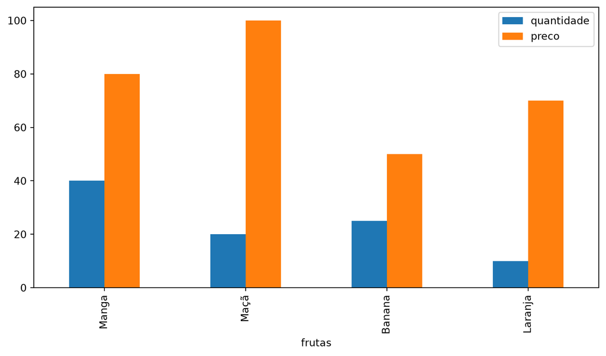

```python
# barras
df_frutas.plot.bar(x='frutas', y=['quantidade', 'preco'])
```

## Gráfico: histograma

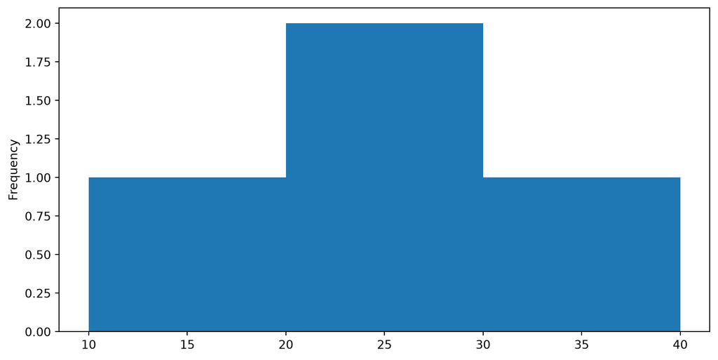

## Gráfico: gráfico de dispersão

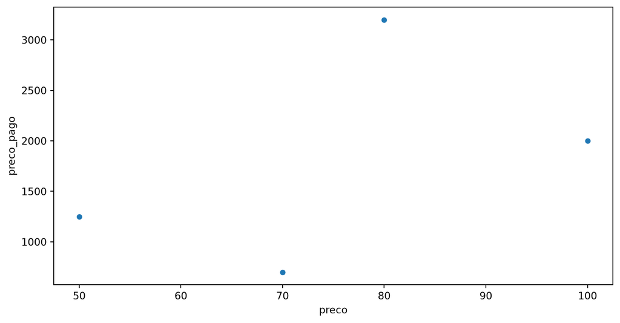

```python
# dispersão
df_frutas.plot.scatter(x='preco', y='preco_pago')
```

## Gráfico: boxplot

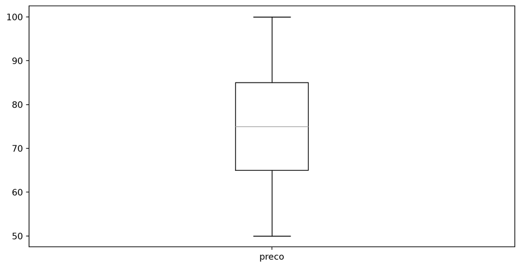

```python
# box-plot (outliers)
df_frutas.boxplot(column='preco', grid=False)
```

## Gráfico: pizza (pie)

```
array([<Axes: >], dtype=object)
```

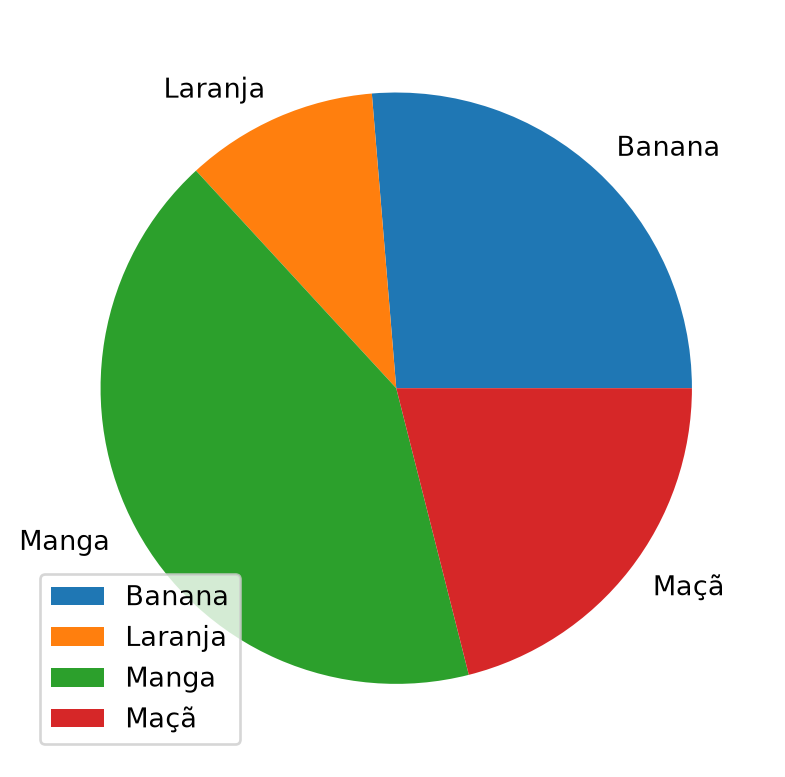

```python
grouped = df_frutas.groupby('frutas').sum()
grouped.plot.pie(y='quantidade', subplots=True)
```

## gráfico com dados PopRua

```python
ax = df_poprua["IDADE"].plot.hist(
    bins=20,
    figsize=(8, 4),
    grid=True,
    color="steelblue",
    title="Idade das pessoas em situação de rua — BH",
    xlabel="idade (anos)",
    ylabel="número de pessoas",
)
```

- `.plot` é um método do **próprio pandas**: a série sabe se desenhar sozinha
- `.plot.hist()` histograma, `.plot.bar()` barras, `.plot.scatter()` dispersão, `.plot.box()` caixa
- Títulos, eixos e cores são **argumentos do próprio `.plot`**: `title=`, `xlabel=`, `ylabel=`, `color=`, `grid=`, `bins=`
- O resultado é um objeto de eixos (`Axes`), que dá para guardar e ajustar

## Exercício 21 no notebook

**Exercício 21 — Primeiro gráfico.** Desenhe um histograma de `IDADE` com 20 faixas e guarde o resultado em `ax`.

```python
# EXERCICIO 21
ax = ...        # .plot.hist com bins=20 e, se quiser, title=/xlabel=/grid=
```

O corretor exige o `.plot` e confere se o gráfico tem barras desenhadas.

## Solução do Exercício 21

```python
# EXERCICIO 21
ax = df_poprua["IDADE"].plot.hist(
    bins=20,
    figsize=(8, 4),
    grid=True,
    color="steelblue",
    title="Idade das pessoas em situação de rua — BH",
    xlabel="idade (anos)",
    ylabel="número de pessoas",
)
```

```
  [OK]     ax é o objeto devolvido pelo gráfico
  [OK]     o gráfico tem barras desenhadas
  Nota: 10.0 / 10   (2 de 2 checagens)
```

Depois do gráfico, o passo natural é **salvar**: `ax.figure.savefig("hist_idade.png", dpi=300)`.

## O fluxo de trabalho em pandas

```
1. importar        pd.read_csv(...)
2. inspecionar     .head()  .shape  .dtypes  .info()
3. descrever       .describe()  .value_counts()
4. filtrar         df[df["col"] > x]   .query(...)
5. agrupar         .groupby("col").size() / .mean() / .agg([...])
6. visualizar      .plot.hist() / .bar() / .scatter()
7. salvar          .to_csv(...)  ax.figure.savefig(...)
```

Este é o esqueleto de praticamente toda análise tabular — a diferença entre uma análise e outra está na pergunta, não no código.

## O que fica para depois

| Tema | Ferramenta |
| --- | --- |
| Juntar duas bases (por chave) | `pd.merge()` |
| Datas e séries temporais | `pd.to_datetime`, `.dt` |
| Dados faltantes | `.isna()`, `.fillna()`, `.dropna()` |
| Tabelas de contingência / proporções | `pd.crosstab()` |
| Gráficos mais bonitos | `seaborn`, `plotnine` (gramática do ggplot2) |
| Mapas | `geopandas` |
| Estatística e modelos | `statsmodels`, `scikit-learn` |
| Texto | `spaCy`, `NLTK`, `scikit-learn` |

# Fechamento

## O que você sabe fazer agora

- Ler um **CSV** e entender o que é uma tabela de dados
- Criar **variáveis**, reconhecer **tipos**, converter o que precisa
- Guardar valores em **listas** e **dicionários**
- Escrever **condições** e **laços** que decidem e repetem
- Empacotar lógica em **funções** reaproveitáveis
- **Importar** uma base no pandas, **descrever**, **filtrar**, **agrupar** e **desenhar**
- Usar o **Colab** sem instalar nada

Isso é o suficiente para fazer, sozinho, a primeira tabela e o primeiro gráfico de qualquer base tabular.

## Para continuar estudando (tudo gratuito)

- Curso Python 101 do DCC https://dcc.ufmg.br/programacao101/
- **Python para Análise de Dados** — Wes McKinney (o livro desta oficina, online em inglês): https://wesmckinney.com/book/
- **Documentação do Python em português**: https://docs.python.org/pt-br/3/tutorial/
- **Automate the Boring Stuff with Python** — Al Sweigart (online): https://automatetheboringstuff.com/
- **Kaggle Learn — Python e Pandas**: https://www.kaggle.com/learn
- **Python para todos** (material em português, UFMG/IME): procure “Python para todos” + “Fernando Masanori”
- **R para Ciência de Dados** — Hadley Wickham (em português): https://pt.r4ds.hadley.nz/

## Do R ao Python (e de volta)

- **Oficina de Introdução ao R** (X Seminário Discente, 2025): https://soaresalisson.github.io/Intro_R_analise_dados/introR.html
- Os conceitos são os mesmos: tipos, vetores/listas, `if`, `for`, funções, e um “pandas” chamado tidyverse
- Trocar de linguagem depois de aprender a primeira é ordens de magnitude mais fácil
- Quem trabalha com dados sociais vai conviver com as duas — e com SQL

## Como praticar nas próximas duas semanas

1. **Escolha uma base** do seu tema (dados abertos, TSE, IBGE, sua própria planilha)
2. Refaça os 21 exercícios com ela: `shape`, `value_counts`, um filtro, um `groupby`, um gráfico
3. Guarde o notebook no GitHub ou no Drive — o hábito de versionar é metade do trabalho
4. Quando travar: documentação → busca → comunidade → LLM (nessa ordem, conferindo sempre)

## Obrigado!

- Slides: https://soaresalisson.github.io/2026_ufmg_python/ (também na capa, no QR)
- Mais slides: Aulas Fundaj: [Introdução Python](https://soaresalisson.github.io/fundaj_2026_pyhton_aula01/) [Pandas](https://soaresalisson.github.io/fundaj_python_pandas/)
- Contatos:
  - e-mail: alissoares@ufmg.br
  - GitHub: https://github.com/SoaresAlisson
  - BlueSky: [@alissonmasoares.bsky.social](https://bsky.app/profile/alissonmasoares.bsky.social)
  - LinkedIn: https://www.linkedin.com/in/alisson-soares-7b01621bb/

**Perguntas?**